# Paper-plots

# 19 Fig 4H UMAP females offspring BFA

```r
#read in US oject
US <- readRDS("objects/US_OFT_batch12.rds")

#relabel the conditions
US$meta$condition[US$meta$condition == "non stressed PROTAC"] <- "Control-KH103"
US$meta$condition[US$meta$condition == "non-stressed PROTAC"] <- "Control-KH103"
US$meta$condition[US$meta$condition == "non stressed DMSO"] <- "Control-DMSO"
US$meta$condition[US$meta$condition == "non-stressed DMSO"] <- "Control-DMSO"
US$meta$condition[US$meta$condition == "stressed PROTAC"] <- "Stress-KH103"
US$meta$condition[US$meta$condition == "stressed DMSO"] <- "Stress-DMSO"

# table(US$meta$condition)

table(US$meta$condition,US$meta$sex)
```

```
##
##                  f  m
##   Control-DMSO  13 12
##   Control-KH103 10 14
##   Stress-DMSO   15 22
##   Stress-KH103   9 16
```

```r
# US$meta <- US$meta %>%
#   tidyr::separate(condition, into = c("Stress", "Treatment"), sep = " ")
# US$meta
```

split US data in objects of interest

```r
# females
US_f <- SplitUSData(US, omit = US$file_names[US$meta$sex =="m"])



# males
US_m <- SplitUSData(US, omit = US$file_names[US$meta$sex =="f"])
```

```r
x <- Plot2DEmbedding(
    US_f,
    seed = 61,
    transitionmatrices  = "kmeans.50",
    colorby = "condition",
    color = c("seashell3", "seashell4", "#ffa500ff", "tomato3"),
    plot.sem = TRUE,
  ) + ggtitle(paste0("UMAP:Transitions female offspring" ))
```

```
## [1] "including transitionmatrix: kmeans.50"
```

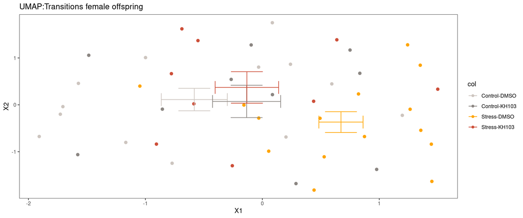

```r
 print(x)
```

```r
ggsave("plots/Fig4H_UMAP_Trans_Females.png")
  ggsave("plots/Fig4H_UMAP_Trans_Females.svg")
   ggsave("plots/Fig4H_UMAP_Trans_Females.pdf")
```

# 20 Fig 4I Female offspring Stress effect

```r
US_list <- readRDS("objects/US_list_OFT_analysed.rds")



US_list <- lapply(US_list,function(us){
  us$meta$Group <- interaction(us$meta$Stress,us$meta$Treatment)
  us
})
```

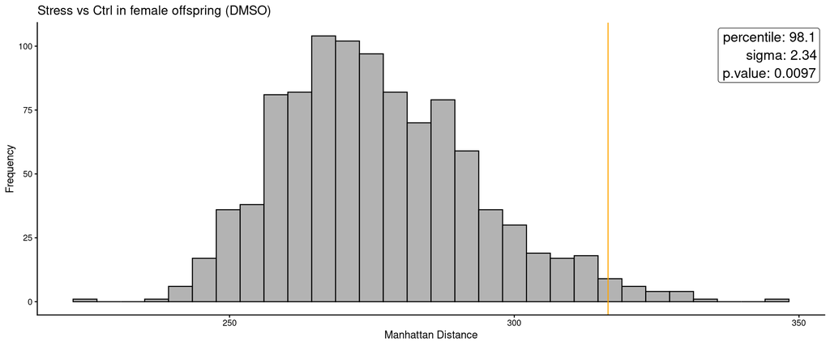

```r
  x <- plotTransVF(US_list$US_f_SvsC_D, labels = "kmeans.50",title = "Stress vs Ctrl in female offspring (DMSO)")
  print(x)
```

```r
ggsave("plots/Fig4I_Perm_Trans_Females_SvsCinDMSO.png")
  ggsave("plots/Fig4I_Perm_Trans_Females_SvsCinDMSO.svg")
   ggsave("plots/Fig4I_Perm_Trans_Females_SvsCinDMSO.pdf")
```

# 21 Fig 4J Female offspring Stress:KH103 effect

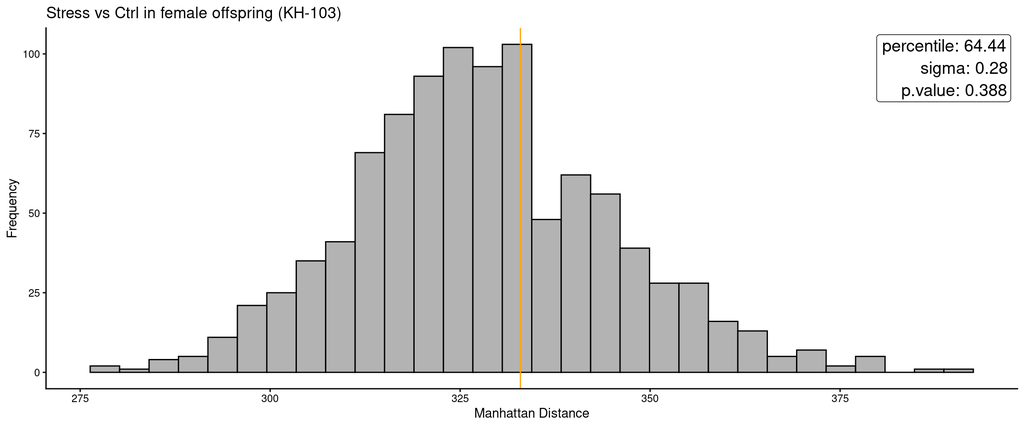

```r
  x <- plotTransVF(US_list$US_f_SvsC_K, labels = "kmeans.50",title = "Stress vs Ctrl in female offspring (KH-103)")
  print(x)
```

```r
ggsave("plots/Fig4J_Perm_Trans_Females_SvsCinKH.png")
  ggsave("plots/Fig4J_Perm_Trans_Females_SvsCinKH.svg")
   ggsave("plots/Fig4J_Perm_Trans_Females_SvsCinKH.pdf")
```

# 22 Fig 4K Female offspring distance covered

read in behavior data

```r
df <- readRDS("objects/OFT_readout.rds")
df$condition <- as.character(df$condition)

df$condition[df$condition == "non.stressed.PROTAC"] <- "Control-KH103"

df$condition[df$condition == "non.stressed.DMSO"] <- "Control-DMSO"

df$condition[df$condition == "stressed.PROTAC"] <- "Stress-KH103"
df$condition[df$condition == "stressed.DMSO"] <- "Stress-DMSO"

df$condition <- factor(df$condition, levels = c("Control-DMSO", "Stress-DMSO", "Control-KH103", "Stress-KH103"))
```

```r
df <- df[df$sex == "f",]
```

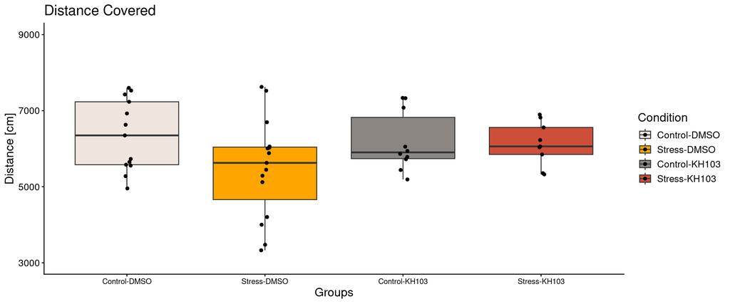

```r
behavior <- "bodycentre.distance.moving"
  # Calculate range and breaks
  y_min <- (min(df[[behavior]]))
  y_max <- (max(df[[behavior]]))
  y_breaks <- seq(3000, 9000, length.out = 4)

  # Round to nearest 0.5
  # round_to_half <- function(x) round(x * 2,digits = 1) / 2
  # y_breaks <- round_to_half(y_breaks)
  #
  # Adjust limits to match rounded breaks
  y_lim <- range(y_breaks)



  e <- ggplot(df, aes(x = condition, y = df[[behavior]], fill = condition))


   e2 <- e + geom_boxplot(width = 0.75,outlier.shape = NA ) +
     geom_jitter(
     position=position_jitterdodge(jitter.width = 0.1, dodge.width = 0.75)
      )+

     ylab("Distance [cm]")+
     xlab("Groups")+
     ggtitle(paste0("Distance Covered"))+



  scale_y_continuous(breaks = y_breaks, limits = y_lim) +


     scale_fill_manual(values=c( "seashell2","#ffa500ff","seashell4","tomato3"))+
     labs(fill= "Condition")+

   theme(
    axis.text.x = element_text(size = 9),
    text = element_text(size = 14),
  )


   print(e2)
```

```r
#
ggsave("plots/Fig4K_DistanceCovered_offspring.svg")
ggsave("plots/Fig4K_DistanceCovered_offspring.pdf")
ggsave("plots/Fig4K_DistanceCovered_offspring.png")
```

# 23 Fig 4I Female Time in Center

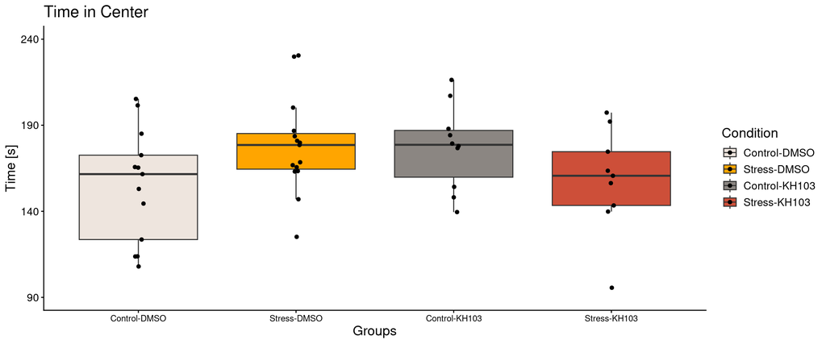

```r
behavior <- "tic1"
  # Calculate range and breaks
  y_min <- (min(df[[behavior]]))
  y_max <- (max(df[[behavior]]))
  y_breaks <- seq(90, 240, length.out = 4)

  # Round to nearest 0.5
  # round_to_half <- function(x) round(x * 2,digits = 1) / 2
  # y_breaks <- round_to_half(y_breaks)
  #
  # Adjust limits to match rounded breaks
  y_lim <- range(y_breaks)



  e <- ggplot(df, aes(x = condition, y = df[[behavior]], fill = condition))


   e2 <- e + geom_boxplot(width = 0.75,outlier.shape = NA ) +
     geom_jitter(
     position=position_jitterdodge(jitter.width = 0.1, dodge.width = 0.75)
      )+

     ylab("Time [s]")+
     xlab("Groups")+
     ggtitle(paste0("Time in Center"))+



  scale_y_continuous(breaks = y_breaks, limits = y_lim) +


     scale_fill_manual(values=c( "seashell2","#ffa500ff","seashell4","tomato3"))+
     labs(fill= "Condition")+

   theme(
    axis.text.x = element_text(size = 9),
    text = element_text(size = 14),
  )


   print(e2)
```

```r
ggsave("plots/Fig4I_TIC_offspring.svg")
ggsave("plots/Fig4I_TIC_offspring.pdf")
ggsave("plots/Fig4I_TIC_offspring.png")
```

# 24 Fig 5B Human sperm accessible sites with GRE

action required –> objects

```r
bw_list <- list.files(path = "intern_data/ATAC_Hs/",pattern = "full.bw$",full.names = T)
names <- gsub(x = basename(bw_list),pattern = "\\.bam|.bw",replacement = "")
names(bw_list) <- names

bw_Human <- bw_list[-length(bw_list)]
```

```r
pfm_list <- list.files(path = "objects//H14CORE-CLUSTERED/pfm",pattern = ".pfm",full.names = T)
```

```r
library(universalmotif)

motifs_cluster <- lapply(pfm_list,function(x){
  y <- read_homer(x)
  y@name <- basename(x)
  y
})

names(motifs_cluster) <- gsub(x = basename(pfm_list),pattern = ".pfm",replacement = "")
```

```r
motifs_cluster <- do.call(what = "PFMatrixList", lapply(motifs_cluster, class="TFBSTools-PFMatrix", FUN= convert_motifs))
```

```r
core <- read_meme(file = "objects/H14CORE_meme_format.meme")


# original function PL
summary_core <- universalmotif::summarise_motifs(core)
core <- setNames(object = core,nm = summary_core$name)

motifs <- core
modf <- data.frame(row.names=summary_core$name,
                     TF=gsub(".H14CORE....+","",summary_core$name),
                     grade=gsub(".+\\.","",summary_core$name),
                     motif_rank = gsub("[^0123]+","",gsub(".*MO.",replacement = "",summary_core$name))) #gsub("[^ro]+", "", str1)
modf <- modf[order(modf$TF,modf$grade,modf$motif_rank),]
modf <- modf[!duplicated(modf$TF),]

modf <- modf[!modf$grade == "D",]
motifs <- setNames(universalmotif::convert_motifs(motifs[row.names(modf)]), modf$TF)
```

genome

```r
genome <- Rsamtools::FaFile("objects/GRCh38.primary_assembly.genome.fa")
```

```r
resizedPeaks300 <- readRDS("objects/narrowPeaks_allHumanHighLow5_resized_300bp.SE.rds")
```

```r
se <- resizedPeaks300
se$names <- gsub(x = colnames(se),pattern = "\\_(.*)",replacement = "")
meta <- read.csv("intern_data/ATAC_Hs/meta.csv",sep = ",")

rownames(meta) <- meta$FB_ID
meta <- meta[complete.cases(meta),]
meta <- meta[se$names,]
colData(se) <- DataFrame(meta[se$names,])
names(bw_Human) <- gsub(x = names(bw_Human),pattern = "\\_(.*)",replacement = "")
```

```r
sequence <- get_sequence(regions = granges(resizedPeaks300),genome = genome, meme_path = "/common/meme/bin/")
fimo <- memes::runFimo(sequences = sequence,motifs = universalmotif::convert_motifs(motifs$GCR), meme_path = "/common/meme/bin/");fimo
```

```
## GRanges object with 2479 ranges and 6 metadata columns:
##          seqnames            ranges strand |           motif_id motif_alt_id
##             <Rle>         <IRanges>  <Rle> |        <character>  <character>
##      [1]     chr1 16476384-16476402      + | GCR.H14CORE.0.PS.A         <NA>
##      [2]     chr1 16657524-16657542      - | GCR.H14CORE.0.PS.A         <NA>
##      [3]     chr1 29259499-29259517      + | GCR.H14CORE.0.PS.A         <NA>
##      [4]     chr1 42886916-42886934      - | GCR.H14CORE.0.PS.A         <NA>
##      [5]     chr1 42886918-42886936      + | GCR.H14CORE.0.PS.A         <NA>
##      ...      ...               ...    ... .                ...          ...
##   [2475]     chrY 11591706-11591724      + | GCR.H14CORE.0.PS.A         <NA>
##   [2476]     chrY 56688662-56688680      + | GCR.H14CORE.0.PS.A         <NA>
##   [2477]     chrY 56717199-56717217      + | GCR.H14CORE.0.PS.A         <NA>
##   [2478]     chrY 56745784-56745802      + | GCR.H14CORE.0.PS.A         <NA>
##   [2479]     chrY 56752848-56752866      + | GCR.H14CORE.0.PS.A         <NA>
##              score    pvalue    qvalue    matched_sequence
##          <numeric> <numeric> <numeric>         <character>
##      [1]   8.55172  6.95e-05        NA AGGTGCACAGCGTACCTGG
##      [2]   9.12069  5.61e-05        NA AGGCGCATGGTGTACTGAG
##      [3]  10.03450  3.92e-05        NA CAGAACGCGTCGTTCCAGT
##      [4]  10.01720  3.95e-05        NA CTGGACACCATGTACGAGG
##      [5]  10.44830  3.31e-05        NA TCGTACATGGTGTCCAGGG
##      ...       ...       ...       ...                 ...
##   [2475]   8.51724  7.04e-05        NA TGGAATGAAATGTACTCGA
##   [2476]   7.62069  9.76e-05        NA TGGAATGAAATGTACTGGA
##   [2477]   7.62069  9.76e-05        NA TGGAATGAAATGTACTGGA
##   [2478]   7.62069  9.76e-05        NA TGGAATGAAATGTACTGGA
##   [2479]   7.62069  9.76e-05        NA TGGAATGAAATGTACTGGA
##   -------
##   seqinfo: 23 sequences from an unspecified genome; no seqlengths
```

```r
seqlevelsStyle(fimo) <- "UCSC"

gr_peaks <- granges(resizedPeaks300)[overlapsAny(granges(resizedPeaks300),subject = fimo),]
length(gr_peaks) # 2067
```

```
## [1] 2067
```

```r
set.seed(123)
seqlevelsStyle(gr_peaks) <- "Ensembl"

nf <- getNormFactors(x = bw_Human,method = "background", peaks = gr_peaks)
sm <- signal2Matrix(c(bw_Human),regions = gr_peaks,w = 10L)
sm_norm <- renormalizeSignalMatrices(sm,scaleFactors = nf)
```

```r
sel <- colnames(sm) %in% colnames(se)[se$TADS_group == "high"]
sm_merge_highTADS <- mergeSignalMatrices(sm_norm[,sel])
sm_merge_lowTADS <- mergeSignalMatrices(sm_norm[,!sel])
```

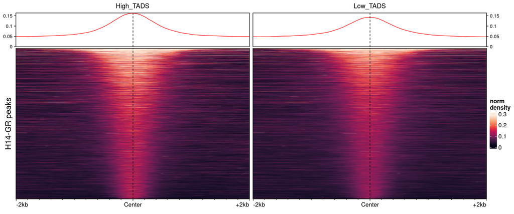

```r
p <- plotEnrichedHeatmaps(ml = list(High_TADS = sm_merge_highTADS, Low_TADS = sm_merge_lowTADS),use_raster = T,row_title = paste0("H14-GR peaks") ,scale_title = "norm\ndensity",colors = rocket(2000) ,axis_name = c("-2kb","Center","+2kb"))
p
```

```r
sel <- colnames(sm) %in% colnames(se)[se$TADS_group == "high"]
sm_merge_highTADS <- mergeSignalMatrices(sm[,sel])
sm_merge_lowTADS <- mergeSignalMatrices(sm[,!sel])
```

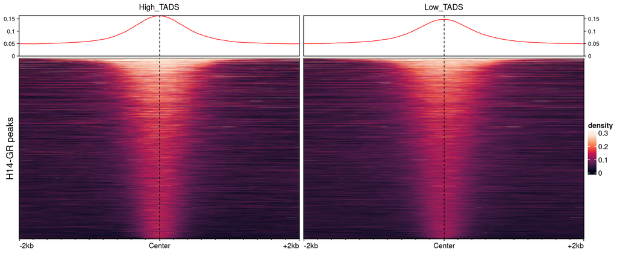

```r
p <- plotEnrichedHeatmaps(ml = list(High_TADS = sm_merge_highTADS, Low_TADS = sm_merge_lowTADS),use_raster = T,row_title = paste0("H14-GR peaks") ,scale_title = "density",colors = rocket(2000) ,axis_name = c("-2kb","Center","+2kb"))
p
```

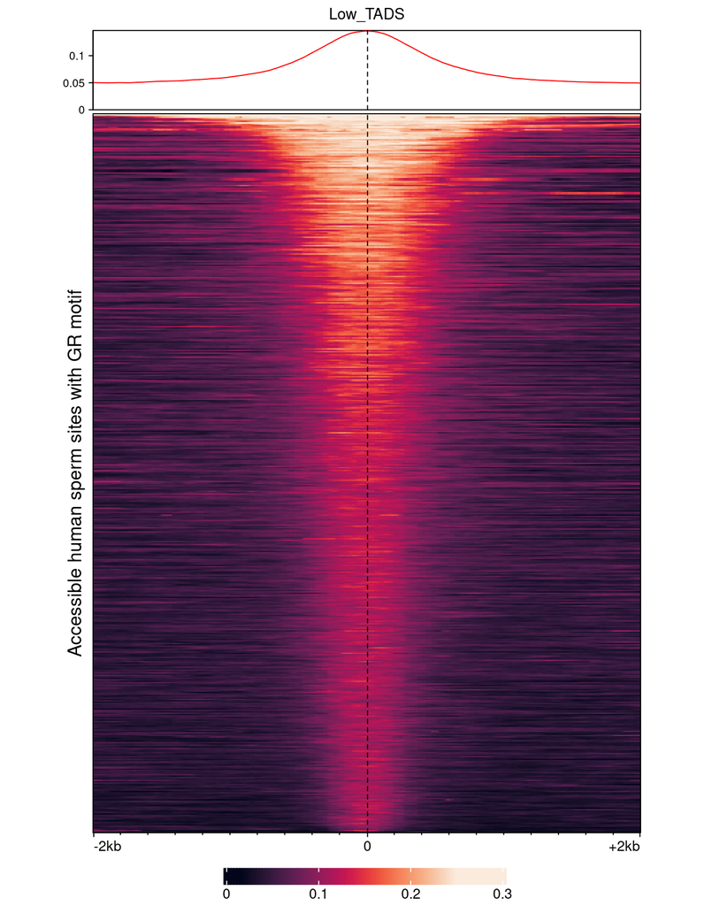

```r
p_GR1 <-  plotEnrichedHeatmaps(list(Low_TADS = sm_merge_lowTADS),row_title = "Accessible human sperm sites with GR motif",scale_title = "GR\ndesnity",colors = rocket(2000), raster_resize_mat = TRUE, use_raster = TRUE,axis_name = c("-2kb","0","+2kb"),width = unit(0.8,"npc"), heatmap_legend_param = list(legend_direction = "horizontal", legend_width = unit(0.4,"npc"), title=NULL))



  draw(p_GR1, heatmap_legend_side="bottom", annotation_legend_side="right",  legend_grouping = "original")
```

```r
  png(paste0("plots/Fig5B_HumanPeaksGCR.png"), width=250, height=500)
  draw(p_GR1, heatmap_legend_side="bottom", annotation_legend_side="right",  legend_grouping = "original")
  dev.off()
```

```r
  # pdf(paste0("plots/Fig5B.pdf"), width=2.5, height=5)
  # draw(p_GR1, heatmap_legend_side="bottom", annotation_legend_side="right",  legend_grouping = "original")
  # dev.off()
  #
  # svg(paste0("plots/Fig5B.svg"), width=2.5, height=5)
  # draw(p_GR1, heatmap_legend_side="bottom", annotation_legend_side="right",  legend_grouping = "original")
  # dev.off()
```

# 25 Fig 5C Human sperm differential accessibile sites High-TADS vs Low-TADS

```r
res <- readRDS(file = "intern_data/ATAC_Hs/res_DAA_glmQFit.rds")
res <- res$HighVSLow
```

```r
generate_volcano_plot <- function(df, title) {
  df$highlight <- df$adj.P.Val < 0.05
  top_genes <- df[order(df$adj.P.Val), ][1:10, ]
  ggplot(df, aes(x=logFC, y=-log10(adj.P.Val))) +
    geom_point(aes(color = highlight)) +
    scale_color_manual(values = c("TRUE" = "orange", "FALSE" = "black")) +
    # geom_text_repel(data = subset(top_genes, highlight == TRUE), aes(label=Gene), size=3.5, min.segment.length = 0, max.overlaps = Inf, nudge_y = 0.1) +
    geom_hline(yintercept=-log10(0.05), linetype="dashed")+
    xlab("logFC") +
    ylab("-log10(adjusted p-value)") +
    theme_classic() +
    theme(legend.position="none") +
    ggtitle(title)
}
```

```r
res$adj.P.Val <- res$FDR
```

```r
plot <- generate_volcano_plot(df = res,title = "Differential Accessibility Regions in sperm of High-TADS vs Low-TADS")
```

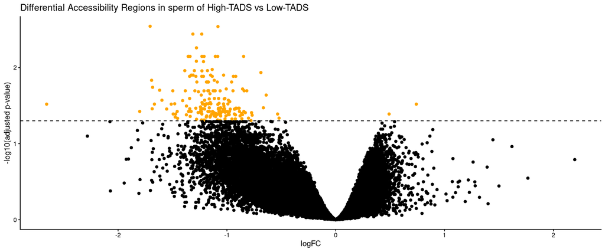

```r
plot
```

```r
# ggsave("plots/NewFig5C_MotifAct_HumanTADS_noGenes_volcano.svg")
# ggsave("plots/NewFig5C_MotifAct_HumanTADS_noGenes_volcano.pdf")
ggsave("plots/Fig5C_MotifAct_HumanTADS_noGenes_volcano.png")
```

# 26 Fig 5D MotifEnrichment in human sperm accessible sites

```r
genome <- Rsamtools::FaFile("objects/GRCh38.primary_assembly.genome.fa")
```

```r
resizedPeaks300 <- readRDS("objects/narrowPeaks_allHumanHighLow5_resized_300bp.SE.rds") ## this

gr <- granges(resizedPeaks300)
```

```r
ame_Hs_cluster <- readRDS("intern_data/ATAC_Hs/ame_HocoCluster_allPeaks.rds")
ame_Hs_cluster$motif <- gsub(x = ame_Hs_cluster$motif_id,pattern = ".H14CORE(.*)pfm",replacement = "")
ame_Hs_cluster[ame_Hs_cluster$motif == "ANDR",]
```

| rank | motif_db | motif_id | motif_alt_id | consensus | pvalue | adj.pvalue | evalue | tests | fasta_max | pos | neg | pwm_min | tp | tp_percent | fp | fp_percent | motif |
| --- | --- | --- | --- | --- | --- | --- | --- | --- | --- | --- | --- | --- | --- | --- | --- | --- | --- |
| 58 | /tmp/RtmpxKWIll/4 | ANDR.H14CORE.2.P.B.pfm | NA | TGTTCYBNNHTGTTTRCWY | 1.85e-305 | 7.74e-305 | 5.01e-305 | 41795 | 78033 | 78033 | 78033 | 1.72 | 18813 | 24.11 | 12350 | 15.83 | ANDR |
| 319 | /tmp/RtmpxKWIll/3 | ANDR.H14CORE.1.S.C.pfm | NA | RTGTTCCH | 3.12e-15 | 1.32e-10 | 8.54e-08 | 42285 | 78033 | 78033 | 78033 | 9.10 | 70 | 0.09 | 6 | 0.01 | ANDR |

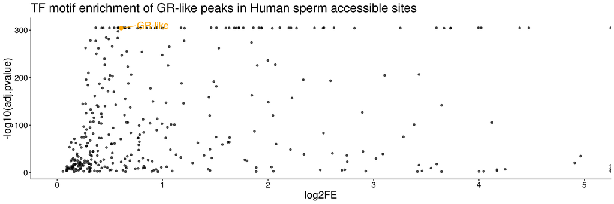

```r
p2 <- ggplot(ame_Hs_cluster, aes(log2(((tp/pos))/((fp/neg))), -log10(adj.pvalue))) +
  geom_point(alpha=0.7, size =1.5) +
  geom_point(data=ame_Hs_cluster[(ame_Hs_cluster$motif_id == "ANDR.H14CORE.2.P.B.pfm"),],colour = "orange", size =3) +
  # geom_text_repel(data=head((ame_Hs_cluster),20), aes(label=motif),max.overlaps = 20, size = 5)+
  labs(x="log2FE")+
  xlim(c(0,5))+
  theme(text = element_text(size = 13))+ggtitle("TF motif enrichment of GR-like peaks in Human sperm accessible sites")+
      geom_text_repel(data=ame_Hs_cluster[(ame_Hs_cluster$motif_id == "ANDR.H14CORE.2.P.B.pfm"),],colour = "orange", label = c("GR-like"),max.overlaps = 20, size = 6,nudge_x = 0.3,nudge_y = 6)+
    # geom_text_repel(data=ame_merge_narrow_threshold_0.05[(ame_merge_narrow_threshold_0.05$motif == "ANDR"),], aes(label=motif),max.overlaps = 20, size = 4)+
    # geom_text_repel(data=ame_merge_narrow_threshold_0.05[(ame_merge_narrow_threshold_0.05$motif == "PRGR"),], aes(label=motif),max.overlaps = 20, size = 4)+
  theme_classic() +
  theme(legend.position = "none",axis.text.x = element_text(size=14),
          axis.text.y = element_text(size=14),
          legend.text = element_text(size=12),
          legend.title = element_text(size = 14),
          text = element_text(size = 18)
    )
p2
```

```r
# ggsave("plots/Fig5D_motifEnrichemnt_GRlike_allPeaks_sperm.svg")
ggsave("plots/Fig5D_motifEnrichemnt_GRlike_allPeaks_sperm.png")
# ggsave("plots/Fig5D_motifEnrichemnt_GRlike_allPeaks_sperm.pdf")
```

# 27 Fig 5E LogFC shift of accessibility in TADS group in peaks with GR-like motif

action required objects

```r
res <- readRDS("intern_data/ATAC_Hs/res_DAA_glmQFit.rds")
res <- res[[1]]
mm <- readRDS("objects/motif_idx_GRlike_300bp.rds")
mm2 <- mm[overlapsAny(GRanges(rownames(mm)),GRanges(rownames(res)))]
res$ID300 <- as.character(resize(GRanges(rownames(res)),width = 300,fix = "center"))
mm2 <- mm2[res$ID300,]

rowData(mm2) <- DataFrame(res)


rowData(mm2)$GRlike <- ifelse(assay(mm2)[,"ANDR.H14CORE.2.P.B.pfm"],yes = "GR-like",no = "Background")
res$GRlike <-ifelse(assay(mm2)[,"ANDR.H14CORE.2.P.B.pfm"],yes = "GR-like",no = "Background")

res$GRlike <- as.factor(res$GRlike)
```

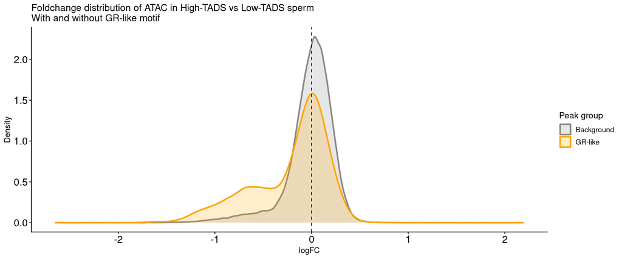

```r
ggplot(res, aes(x = logFC, colour = GRlike, fill = GRlike)) +
  geom_density(alpha = 0.2, linewidth = 1) +
  geom_vline(xintercept = 0, linetype = "dashed") +
  labs(
    colour = "Peak group",
    fill = "Peak group"
  ) +
  scale_fill_manual( values = c(
    "Background" = "seashell4",
    "GR-like" = "#ffa500ff")) +        #"seashell2","#ffa500ff","seashell4","tomato3
    scale_color_manual( values = c(
    "Background" = "seashell4",
    "GR-like" = "#ffa500ff")) +
  xlab("logFC") +
    ylab("Density") +
    theme_classic() +
    theme(legend.position="none") +
  theme_classic()+
  theme(axis.text.x = element_text(size=14),
        axis.title.x = element_text(hjust = 0.54),
          axis.text.y = element_text(size=14),
          legend.text = element_text(size=10),
          legend.title = element_text(size = 12),
          # text = element_text(size = 18)
    )+
  ggtitle("Foldchange distribution of ATAC in High-TADS vs Low-TADS sperm\nWith and without GR-like motif")
```

```r
# ggsave("plots/Fig5E_logFCshift_TADS.svg")
# ggsave("plots/Fig5E_logFCshift_TADS.pdf")
ggsave("plots/Fig5E_logFCshift_TADS.png")
```

```r
ks.test(logFC ~ GRlike, data = res)
```

```
##
##  Asymptotic two-sample Kolmogorov-Smirnov test
##
## data:  logFC by GRlike
## D = 0.23537, p-value < 2.2e-16
## alternative hypothesis: two-sided
```

```r
coin::wilcox_test(logFC ~ GRlike, data = res,distribution = coin::approximate(nresample = 10000))
```

```
##
##  Approximative Wilcoxon-Mann-Whitney Test
##
## data:  logFC by GRlike (Background, GR-like)
## Z = 37.852, p-value < 1e-04
## alternative hypothesis: true mu is not equal to 0
```

# 28 Fig 5F LogFC shift of GR-signal in IFS mouse sperm in accessible peaks with GR-like motif

```r
res <- readRDS("intern_data/ATAC_Hs/res_glmQFFit_GRsignalATAC.rds")
mm <- readRDS("intern_data/ATAC_Hs/motif_idx_GRlike_GRSignalinATAC_resized_SE.rds")


mm2 <- mm[overlapsAny(GRanges(rownames(mm)),GRanges(rownames(res)))]

mm2 <- mm2[rownames(res),]

rowData(mm2) <- DataFrame(res)



rowData(mm2)$GRlike <- ifelse(assay(mm2)[,"ANDR.H14CORE.2.P.B.pfm"],yes = "GR-like",no = "Background")
res$GRlike <-ifelse(assay(mm2)[,"ANDR.H14CORE.2.P.B.pfm"],yes = "GR-like",no = "Background")

res$GRlike <- as.factor(res$GRlike)
```

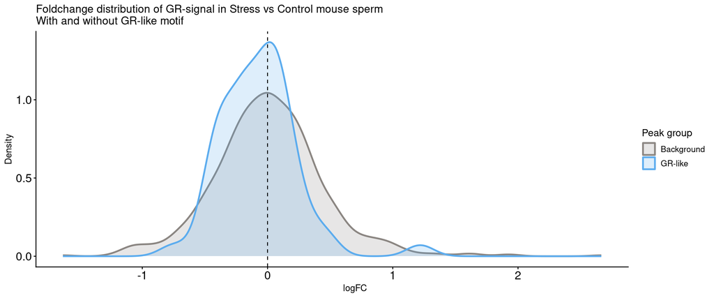

```r
ggplot(res, aes(x = logFC, colour = GRlike, fill = GRlike)) +
  geom_density(alpha = 0.2, linewidth = 1) +
  geom_vline(xintercept = 0, linetype = "dashed") +
  labs(
    colour = "Peak group",
    fill = "Peak group"
  ) +
  scale_fill_manual( values = c(
    "Background" = "seashell4",
    "GR-like" = "steelblue2")) +        #"seashell2","#ffa500ff","seashell4","tomato3
    scale_color_manual( values = c(
    "Background" = "seashell4",
    "GR-like" = "steelblue2")) +
  xlab("logFC") +
    ylab("Density") +
    theme_classic() +
    theme(legend.position="none") +
  theme_classic()+
  theme(axis.text.x = element_text(size=14),
        axis.title.x = element_text(hjust = 0.54),
          axis.text.y = element_text(size=14),
          legend.text = element_text(size=10),
          legend.title = element_text(size = 12),
          # text = element_text(size = 18)
    )+
  ggtitle("Foldchange distribution of GR-signal in Stress vs Control mouse sperm\nWith and without GR-like motif")
```

```r
ggsave("plots/Fig5E_logFCshift_StressMouse_blue.svg")
ggsave("plots/Fig5E_logFCshift_StressMouse_blue.pdf")
ggsave("plots/Fig5E_logFCshift_StressMouse_blue.png")
```

## 28.1 Fig S5B LogFC attenuation of Stress:Sex interaction in offspring HC transcriptome originating from KH103 treated sperm

action required objects

```r
se <- readRDS("objects/se_HPP_offspring_with_DEA_result.rds")
deas <- getDEA(se)
results_DMSO_stressSex_int <-deas$DMSO_interaction_between_sex_n_stress
results_DMSO_stressSex_int$ID <- rownames(results_DMSO_stressSex_int)
results_DMSO_stressSex_int$Treatment <- "DMSO"

results_PROTAC_stressSex_int <-deas$PROTAC_interaction_between_sex_n_stress
results_PROTAC_stressSex_int$ID <- rownames(results_PROTAC_stressSex_int)
results_PROTAC_stressSex_int$Treatment <- "PROTAC"

results_both_stressSex_int <- deas$bothdrug_interaction_between_sex_n_stress
results_both_stressSex_int$ID <- rownames(results_both_stressSex_int)
results_both_stressSex_int$Treatment <- "Both"

merge2 <- rbind(results_DMSO_stressSex_int,results_PROTAC_stressSex_int)
```

```r
merge2$Treatment2 <- as.factor(ifelse(merge2$Treatment == "PROTAC",yes = "KH103",no = "DMSO"))
```

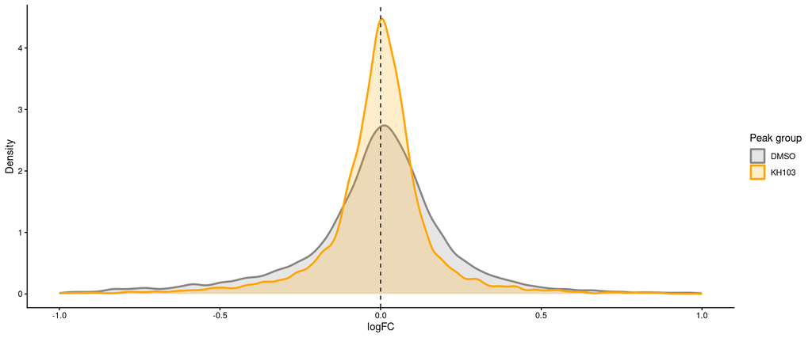

```r
ggplot(merge2, aes(x = (logFC), colour = Treatment2, fill = Treatment2)) +
  geom_density(alpha = 0.2, linewidth = 1) +
  geom_vline(xintercept = 0, linetype = "dashed") +
  labs(
    x = "logFC",
    y = "Density",
    colour = "Peak group",
    fill = "Peak group"
  ) +
    scale_fill_manual( values = c(
    "DMSO" = "seashell4",
    "KH103" = "#ffa500ff")) +        #"seashell2","#ffa500ff","seashell4","tomato3
    scale_color_manual( values = c(
    "DMSO" = "seashell4",
    "KH103" = "#ffa500ff")) +
  xlim(c(-1,+1))+
  theme_classic()
```

```r
ggsave("plots/FigS5B_KH103_attenuation_HC.png")
ggsave("plots/FigS5B_KH103_attenuation_HC.pdf")
ggsave("plots/FigS5B_KH103_attenuation_HC.svg")
```

```r
merge2$Treatment <- factor(x = merge2$Treatment)
merge2$ID <- factor(x = merge2$ID)
```

```r
ks.test(logFC ~ Treatment, data = merge2)
```

```
##
##  Asymptotic two-sample Kolmogorov-Smirnov test
##
## data:  logFC by Treatment
## D = 0.095562, p-value < 2.2e-16
## alternative hypothesis: two-sided
```

```r
coin::wilcoxsign_test(abs(logFC) ~ Treatment|ID, data = merge2,distribution = coin::approximate(nresample = 10000))
```

```
##
##  Approximative Wilcoxon-Pratt Signed-Rank Test
##
## data:  y by x (pos, neg)
##   stratified by block
## Z = 43.775, p-value < 1e-04
## alternative hypothesis: true mu is not equal to 0
```

## 28.2 Fig S5C GSEA of offspring HC transcriptome originating from KH103 treated sperm

```r
dir_path <- "objects/"
files <- list.files(path = dir_path, pattern = "^fgsea_.*", full.names = TRUE)
```

```r
get_top_table <- function(pattern = NULL, filelist, top_num){
  library(purrr)
  library(dplyr)

    # the pattern should be the the pattern of the pathway names that we want to extract
    # for example "C5:GP:BP"
    # top_num: how many top terms we extract from each contrast
    if (is.null(pattern)){
        top_list <- map_dfr(filelist, function(fpath) {
        df <- readRDS(fpath)
        df <- df[order(df$pval), ]
        df_top <- head(df, top_num)  # now choose top5 otherwise too many terms
        fname <- basename(fpath)
        label <- gsub("^fgsea_", "", fname)
        df_top %>%
            mutate(source_file = fname,
                source = label,
                .before = 1)  # put source in column1
    })
    }
    else {
        top_list <- map_dfr(filelist, function(fpath) {
        df <- readRDS(fpath)
        df <- df[order(df$pval), ]
        df_top <- head(df[grepl(pattern, df$pathway),], top_num)  # extract the terms
        fname <- basename(fpath)
        label <- gsub("^fgsea_", "", fname)
        df_top %>%
            mutate(source_file = fname,
                source = label,
                .before = 1)  # put source at column1
})
    }

    top_path <- unique(top_list$pathway)
    fgsea_combine <- map_dfr(filelist, function(f){
        df <- readRDS(f)
        matched <- df %>% dplyr::filter(pathway %in% top_path)
        matched %>%
            mutate(
                label = gsub("^fgsea_", "", basename(f)),
                .before = 1)
    })

    fgsea_combine$label <- gsub("\\.rds$", "", fgsea_combine$label)

    return(fgsea_combine)
}
```

```r
fgsea_combine_GOBP <- get_top_table(pattern = "C5:GO:BP", filelist = files, top_num = 10)
fgsea_combine_GOBP$label <- factor(fgsea_combine_GOBP$label, levels = c(
        "total_stress_vs_ctrl", "total_PROTAC_vs_DMSO", "DMSO_interaction_between_sex_n_stress", "PROTAC_interaction_between_sex_n_stress"
    ))
```

```r
get_cluster <- function(maxK, fgsea_table){ # the function will decide the cluster number by itself (silhouette)
  library(tidyr)
  # First: create a pathway x label matrix, the values are NES (we do the cluster based on NES)
    mat_df <- fgsea_table %>%
        dplyr::select(label, pathway, NES) %>%
        pivot_wider(names_from = label, values_from = NES)
    mat <- as.matrix(mat_df %>% dplyr::select(-pathway))
    rownames(mat) <- mat_df$pathway

    # Second: compute the distance
    # Pearson correlation distance (1 - correlation): measures similarity in patterns, ignoring magnitude
    # Euclidean distance: measures absolute numeric differneces (magnitude)
    # here we care about the pattern across contrast groups, so we use the pearson correlation
    dist_mat <- as.dist(1 - cor(t(mat)))

    # Third: compute hierarchical clustering
    hc <- hclust(dist_mat, method = "ward.D2")  # ward.D2: join clusters that cause the smallest increase in within-cluster variance. good for forming compact balanced clusters from continuous data

    # Fouth: use silhouette to check how many clusters are the best
    avg_sil <- numeric(maxK)
    for(k in 3:maxK){
        cl <- cutree(hc, k= k)
        sil <- cluster::silhouette(cl, dist_mat)
        avg_sil[k] <- mean(sil[,3])
    }
    best_k_sil <- which.max(avg_sil)

    plot(3:maxK, avg_sil[3:maxK], type="b", xlab="k", ylab="Average silhouette", pch=19)
    cat("Best k by silhouette =", best_k_sil, ", avg silhouette =", avg_sil[best_k_sil], "\n")

    pathway_order <- hc$labels[hc$order]
    clusters <- cutree(hc, k = best_k_sil)
    cluster_df <- tibble(pathway = names(clusters), cluster = as.factor(clusters))

    # Put the cluster result into the original table
    fgsea_clustered <- fgsea_table %>%
        left_join(cluster_df, by = "pathway") %>%
        mutate(pathway = factor(pathway, levels = pathway_order))

    return(fgsea_clustered)
}
```

```r
set.seed(123)
fgsea_combine_GOBP_clustered <- get_cluster(maxK = 5, fgsea_table = fgsea_combine_GOBP)
```

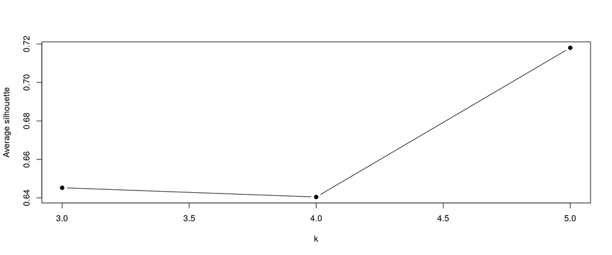

```
## Best k by silhouette = 5 , avg silhouette = 0.7180327
```

```r
cluster_bar_combine_GOBP_clustered <- fgsea_combine_GOBP_clustered %>% distinct(pathway, cluster)
```

```r
fgsea_combine_GOBP_clustered$pathway <- gsub(pattern = "C5:GO:BP:GOBP_",replacement = "",x =fgsea_combine_GOBP_clustered$pathway )
cluster_bar_combine_GOBP_clustered$pathway<- gsub(pattern = "C5:GO:BP:GOBP_",replacement = "",x =cluster_bar_combine_GOBP_clustered$pathway)
```

```r
fgsea_combine_GOBP_clustered$label <- factor(
  fgsea_combine_GOBP_clustered$label,
  levels = c("total_stress_vs_ctrl", "total_PROTAC_vs_DMSO", "DMSO_interaction_between_sex_n_stress", "PROTAC_interaction_between_sex_n_stress"),
  labels= c("Stress vs Ctrl","KH-103 vs DMSO","Ineraction Stress:Sex (DMSO)","Ineraction Stress:Sex (KH-103)")
)
```

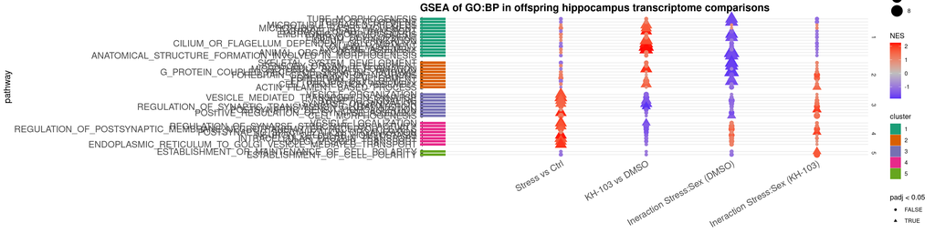

```r
p_combine_GOBP_clustered_with_shape <- ggplot(fgsea_combine_GOBP_clustered, aes(x = label, y = pathway, color = NES, size = -log10(padj), shape = padj<0.05)) +
    geom_point() +
    theme_minimal() +
    scale_color_gradient2(low = "blue", high = "red", mid="grey") +
    scale_size_continuous(range = c(2, 8)) +
    theme(
        axis.text.x = element_text(angle = 90, vjust = 0.5, hjust = 1, size = 14),
        axis.text.y = element_text(size = 14),
        axis.title.x = element_text(size = 14),
        axis.title.y = element_text(size = 14),
        plot.title = element_text(size = 16, face = "bold")
    ) +
    labs(title = "GSEA of GO:BP in offspring hippocampus transcriptome comparisons")+
    xlab(NULL)+
    # label the clusters
    geom_text(data = fgsea_combine_GOBP_clustered %>% dplyr::filter(!duplicated(pathway)),
        aes(x = -Inf, y = pathway, label = cluster),
        inherit.aes = FALSE, hjust = -0.1, size = 3) +
    coord_cartesian(clip = "off") +
    facet_grid(cluster ~ ., scales = "free_y", space = "free_y") +  # to make a little gap between clusters
    geom_tile(data = cluster_bar_combine_GOBP_clustered,  #REMEMBER TO CHANGE
            aes(x = -0.5, y = pathway, fill = cluster),
            width = 0.3, height = 0.8,
            inherit.aes = FALSE)+
  scale_fill_brewer(palette = "Dark2") +

  theme(
    axis.text.x = element_text(angle = 30, hjust = 1, vjust = 1)
  )

p_combine_GOBP_clustered_with_shape
```

```r
ggsave("plots/FigS5C_GSEA_Offspring_HPP.svg")
ggsave("plots/FigS5C_GSEA_Offspring_HPP.pdf")#, width = 6, height = 4)
ggsave("plots/FigS5C_GSEA_Offspring_HPP.png")
```

## 28.3 Fig S5D Offspring HC Fkbp5 expression

```r
df <- as.data.frame(cbind(colData(se),t(assays(se)$logcpm)))
colnames(df) <- gsub(pattern = "^ENSMUS(.*)\\.",replacement = "",x = colnames(df))
df <- df[,!duplicated(colnames(df))]
df$condition <- as.character(df$condition)
df$condition <- factor(df$condition, levels = c("ctrl_DMSO","stress_DMSO","ctrl_PROTAC","stress_PROTAC"))
df$sex <- factor(df$sex, levels = c("f","m"))
```

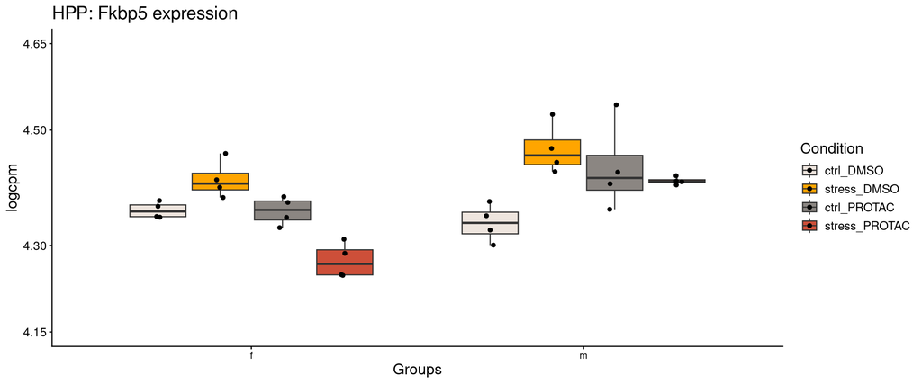

```r
gene <- "Fkbp5"
  # Calculate range and breaks
  y_min <- (min(df[[gene]]))
  y_max <- (max(df[[gene]]))
  y_breaks <- seq(y_min-0.1, y_max+0.1, length.out = 4)

  # Round to nearest 0.5
  round_to_half <- function(x) round(x * 2,digits = 1) / 2
  y_breaks <- round_to_half(y_breaks)

  # Adjust limits to match rounded breaks
  y_lim <- range(y_breaks)



  e <- ggplot(df, aes(x = sex, y = df[[gene]], fill = condition))


   e2 <- e + geom_boxplot(width = 0.75,outlier.shape = NA ) +
     geom_jitter(
     position=position_jitterdodge(jitter.width = 0.1, dodge.width = 0.75)
      )+

     ylab("logcpm")+
     xlab("Groups")+
     ggtitle(paste0("HPP: ",gene," expression"))+



  scale_y_continuous(breaks = y_breaks, limits = y_lim) +


     scale_fill_manual(values=c( "seashell2","#ffa500ff","seashell4","tomato3"))+
     labs(fill= "Condition")+

   theme(
    axis.text.x = element_text(size = 9),
    text = element_text(size = 14),
  )


   print(e2)
```

```r
ggsave("plots/FigS5D_Fkbp5_offspring.svg")
ggsave("plots/FigS5D_Fkbp5_offspring.pdf")
ggsave("plots/FigS5D_Fkbp5_offspring.png")
```

## 28.4 Fig S5E Cort response all groups

```r
df <- read.csv("objects/CortOffspring.csv")
df$Group3 <- interaction(df$stress,df$treatment)
```

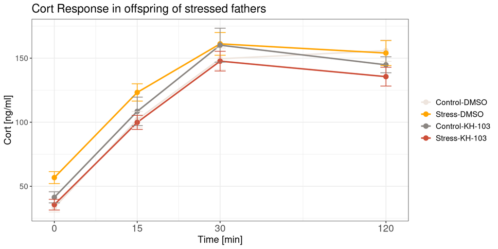

```r
df3 <- df

df3$x_pos <- as.numeric(as.character(df3$time))

df3$x_pos[df3$time == "180"] <- 60




library(ggplot2)

gg <- ggplot(df3, aes(x = x_pos,
               y = corticosterone,
               color = Group3,
               group = Group3)) +

  # mean line
  stat_summary(fun = mean,
               geom = "line",
               size = 1) +

  # points at each timepoint (mean)
  stat_summary(fun = mean,
               geom = "point",
               size = 3) +

  # error bars: mean ± SEM
  stat_summary(
    fun.data = mean_se,   # mean ± standard error
    geom = "errorbar",
    width = 2,
    # linewidth = 0.8
  ) +
    scale_color_manual(values=c( "seashell2","#ffa500ff","seashell4","tomato3"),labels = c("Control-DMSO","Stress-DMSO","Control-KH-103","Stress-KH-103"))+ #  scale_color_manual(values=c( "seashell2","#ffa500ff","seashell4","tomato3"))+

 scale_x_continuous(
    breaks = c(0, 15, 30, 60),
    labels = c("0", "15", "30", "120")
  ) +

 labs(color= NULL)+
  theme_bw() +
   theme(
  axis.text.x = element_text(size = 14),
  text = element_text(size = 14),
)+

  labs(
    x = "Time [min]",
    y = "Cort [ng/ml]",
    title = "Cort Response in offspring of stressed fathers"
   )

print(gg)
```

```r
 ggsave("plots/FigS5E_CortResponse.svg")
 ggsave("plots/FigS5E_CortResponse.png")
 ggsave("plots/FigS5E_CortResponse.pdf")
```

## 28.5 Fig S5F Behavior assessment sex effect in offspring

```r
#read in US oject
US <- readRDS("objects/US_OFT_batch12.rds")

#relabel the conditions
US$meta$condition[US$meta$condition == "non stressed PROTAC"] <- "Control-KH103"
US$meta$condition[US$meta$condition == "non-stressed PROTAC"] <- "Control-KH103"
US$meta$condition[US$meta$condition == "non stressed DMSO"] <- "Control-DMSO"
US$meta$condition[US$meta$condition == "non-stressed DMSO"] <- "Control-DMSO"
US$meta$condition[US$meta$condition == "stressed PROTAC"] <- "Stress-KH103"
US$meta$condition[US$meta$condition == "stressed DMSO"] <- "Stress-DMSO"

# table(US$meta$condition)

table(US$meta$condition,US$meta$sex)
```

```
##
##                  f  m
##   Control-DMSO  13 12
##   Control-KH103 10 14
##   Stress-DMSO   15 22
##   Stress-KH103   9 16
```

```r
# US$meta <- US$meta %>%
#   tidyr::separate(condition, into = c("Stress", "Treatment"), sep = " ")
# US$meta
```

split US data in objects of interest

```r
# females
US_f <- SplitUSData(US, omit = US$file_names[US$meta$sex =="m"])



# males
US_m <- SplitUSData(US, omit = US$file_names[US$meta$sex =="f"])
```

```r
x <- Plot2DEmbedding(
    US,
    seed = 61,
    transitionmatrices  = "kmeans.50",
    colorby = "condition",
    color = c("seashell3", "seashell4", "#ffa500ff", "tomato3"),
    plot.sem = TRUE,
  ) + ggtitle(paste0("UMAP:Transitions all offspring" ))
```

```
## [1] "including transitionmatrix: kmeans.50"
```

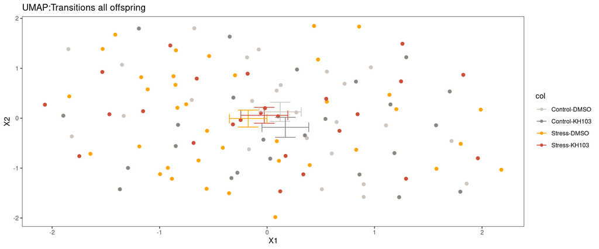

```r
 print(x)
```

```r
ggsave("plots/FigS5FA_UMAP_Trans_Females.png")
  ggsave("plots/FigS5FA_UMAP_Trans_Females.svg")
   ggsave("plots/FigS5FA_UMAP_Trans_Females.pdf")
```

```r
matrix_list_reduced <- lapply(US$files,function(animal){
  as.vector(animal$transmatrix$kmeans.50)
})

matrix_df <- do.call(rbind, matrix_list_reduced)
dist_matrix <- dist(matrix_df,method = "manhattan")


meta <- US$meta

library(tidyr)

meta <- meta %>%
  separate_wider_delim(
    condition,
    delim = "-",
    names = c("condition2", "treatment")
  )
```

```r
library(vegan)
form <- ~ batch + condition2*treatment*sex


form_adonis <- as.formula(
    paste(
        "dist_matrix ~ ",
        paste(attr(terms(form), "term.labels"), collapse = " + ")
    )
)

form_adonis
```

```
## dist_matrix ~ batch + condition2 + treatment + sex + condition2:treatment +
##     condition2:sex + treatment:sex + condition2:treatment:sex
```

```r
res <- adonis2(formula = form_adonis,

    data = meta,
    permutations = 9999,
    by = "terms"
)
res
```

|  | Df | SumOfSqs | R2 | F | Pr(>F) |
| --- | --- | --- | --- | --- | --- |
| batch | 1 | 655040.0 | 0.014778057 | 1.6524979 | 0.0023 |
| condition2 | 1 | 385019.2 | 0.008686241 | 0.9713047 | 0.5286 |
| treatment | 1 | 411391.4 | 0.009281212 | 1.0378349 | 0.3347 |
| sex | 1 | 585478.8 | 0.013208719 | 1.4770129 | 0.0094 |
| condition2:treatment | 1 | 471901.3 | 0.010646349 | 1.1904860 | 0.0979 |
| condition2:sex | 1 | 557429.9 | 0.012575919 | 1.4062525 | 0.0166 |
| treatment:sex | 1 | 374252.7 | 0.008443343 | 0.9441435 | 0.6148 |
| condition2:treatment:sex | 1 | 452491.9 | 0.010208461 | 1.1415209 | 0.1508 |
| Residual | 102 | 40432173.6 | 0.912171698 | NA | NA |
| Total | 110 | 44325178.8 | 1.000000000 | NA | NA |

```r
library(vegan); library(ggplot2); library(dplyr); library(tidyr)

# 1) Refit: only the term of interest, treatment and batch partialled out
cap2 <- capscale(dist_matrix ~ condition2 * sex + Condition(treatment + batch),
                 data = meta)

anova(cap2, by = "margin", permutations = how(nperm = 9999))  # confirm the interaction
```

|  | Df | Variance | F | Pr(>F) |
| --- | --- | --- | --- | --- |
| condition2:sex | 1 | 5280.859 | 1.462426 | 0.0094 |
| Residual | 105 | 379157.771 | NA | NA |

```r
RsquareAdj(cap2)
```

```
## $r.squared
## [1] 0.03508355
##
## $adj.r.squared
## [1] 0.008351384
```

```r
# 2) Scores (3 constrained axes: condition2, sex, condition2:sex)
sc <- scores(cap2, display = "wa", choices = 1:3, scaling = 1) |>
  as.data.frame() |>
  tibble::rownames_to_column("filename") |>
  left_join(meta, by = "filename")

# 3) Interaction plot: mean ± SE per condition2 x sex
cent <- sc |>
  pivot_longer(starts_with("CAP"), names_to = "axis", values_to = "score") |>
  group_by(condition2, sex, axis) |>
  summarise(m = mean(score), se = sd(score) / sqrt(n()), n = n(), .groups = "drop")
```

```r
# variance explained per axis (as % of total variance, not just of constrained)
eig  <- cap2$CCA$eig
tot  <- cap2$tot.chi
lab  <- sprintf("CAP%d (%.1f%% of total variance)", 1:length(eig), 100 * eig / tot)

# group centroids
cent <- sc |>
  group_by(condition2, sex) |>
  summarise(CAP1 = mean(CAP1), CAP2 = mean(CAP2), .groups = "drop")


sc$Condition <- sc$condition2
cent$Condition <- cent$condition2

cols <-  c(
    "Control" = "seashell4",
    "Stress" = "#ffa500ff")

p <- ggplot(sc, aes(CAP1, CAP2, colour = Condition, shape = sex)) +
  stat_ellipse(aes(group = interaction(Condition, sex)),
               level = 0.68, linewidth = 0.4, show.legend = F) +
  geom_point(size = 2.5, alpha = 0.7) +
  geom_point(data = cent, size = 5, stroke = 1.5, shape = 23,
             aes(fill = Condition), colour = "black") +
  scale_colour_manual(values = cols) +
  scale_fill_manual(values = cols) +
  labs(x = lab[1], y = lab[2]) +
  theme_minimal() +
  theme(panel.grid = element_blank(),
        axis.text = element_blank(), axis.ticks = element_blank(),
        panel.border = element_rect(fill = NA, colour = "grey60"))
```

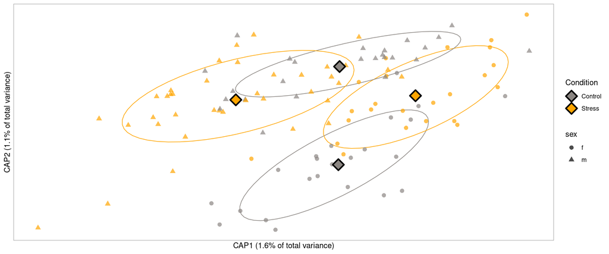

```r
p
```

```r
ggsave("plots/FigS5FB_CAP.png")
ggsave("plots/FigS5FB_CAP.pdf")
ggsave("plots/FigS5FB_CAP.svg")
```

```r
US_list <- readRDS("objects/US_list_OFT_analysed.rds")



US_list <- lapply(US_list,function(us){
  us$meta$Group <- interaction(us$meta$Stress,us$meta$Treatment)
  us
})
```

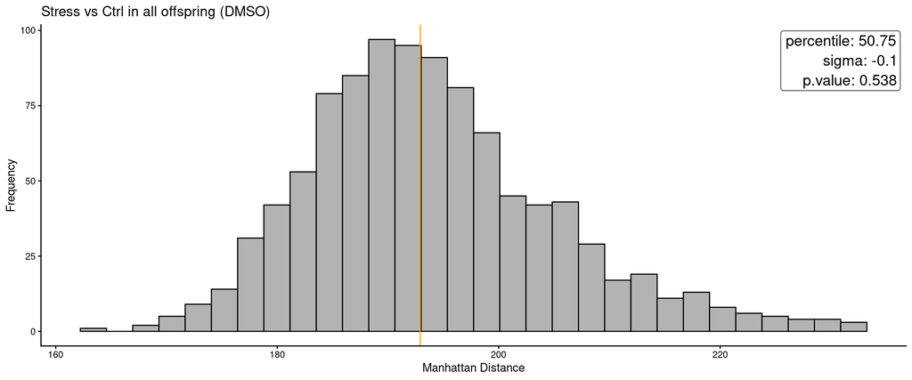

```r
  x <- plotTransVF(US_list$US_SvsC_D, labels = "kmeans.50",title = "Stress vs Ctrl in all offspring (DMSO)")
  print(x)
```

```r
ggsave("plots/FigS5FC_Perm_Trans_all_SvsCinDMSO.png")
  ggsave("plots/FigS5FC_Perm_Trans_all_SvsCinDMSO.svg")
   ggsave("plots/FigS5FC_Perm_Trans_all_SvsCinDMSO.pdf")
```

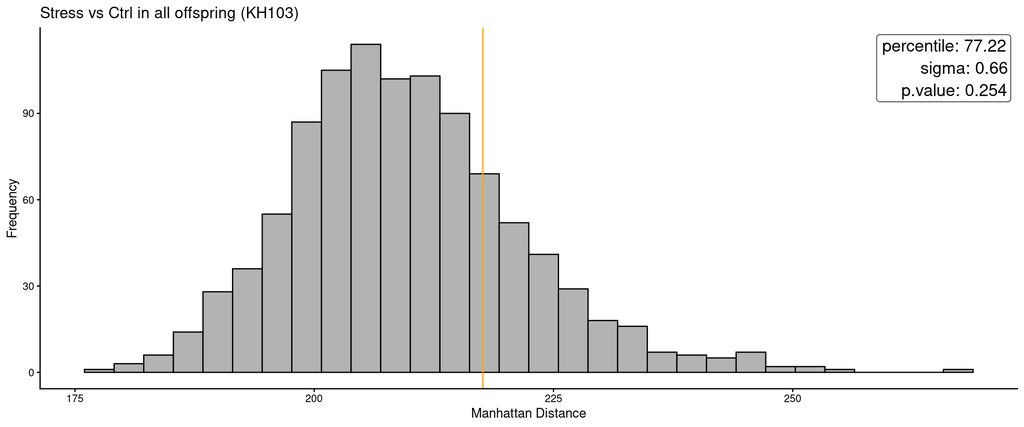

```r
  x <- plotTransVF(US_list$US_SvsC_K, labels = "kmeans.50",title = "Stress vs Ctrl in all offspring (KH103)")
  print(x)
```

```r
ggsave("plots/FigS5FD_Perm_Trans_all_SvsCinKH103.png")
  ggsave("plots/FigS5FD_Perm_Trans_all_SvsCinKH103.svg")
   ggsave("plots/FigS5FD_Perm_Trans_all_SvsCinKH103.pdf")
```

## 28.6 Fig S5G Behavior assessment male offspring

```r
# males
US_m <- SplitUSData(US, omit = US$file_names[US$meta$sex =="f"])
```

```r
x <- Plot2DEmbedding(
    US_m,
    seed = 61,
    transitionmatrices  = "kmeans.50",
    colorby = "condition",
    color = c("seashell3", "seashell4", "#ffa500ff", "tomato3"),
    plot.sem = TRUE,
  ) + ggtitle(paste0("UMAP:Transitions male offspring" ))
```

```
## [1] "including transitionmatrix: kmeans.50"
```

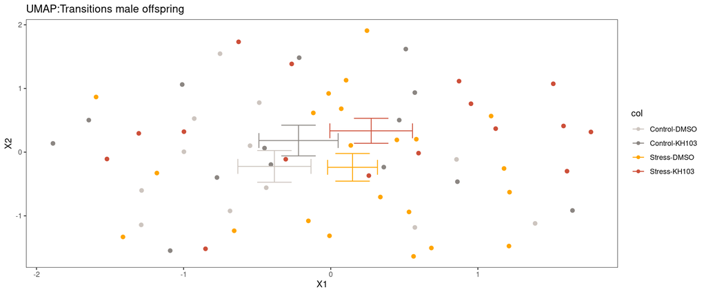

```r
 print(x)
```

```r
  ggsave("plots/FigS5GA_UMAP_Trans_Males.png")
  ggsave("plots/FigS5GA_UMAP_Trans_Males.svg")
   ggsave("plots/FiS5GA_UMAP_Trans_Males.pdf")
```

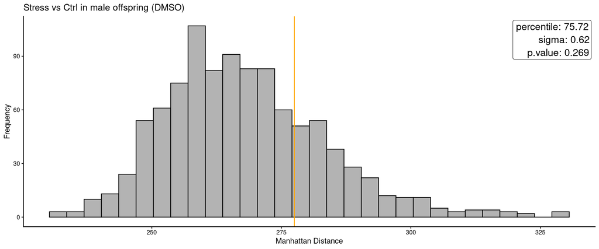

```r
  x <- plotTransVF(US_list$US_m_SvsC_D, labels = "kmeans.50",title = "Stress vs Ctrl in male offspring (DMSO)")
  print(x)
```

```r
ggsave("plots/FigS5GB_Perm_Trans_male_SvsCinDMSO.png")
  ggsave("plots/FigS5GB_Perm_Trans_male_SvsCinDMSO.svg")
   ggsave("plots/FigS5GB_Perm_Trans_male_SvsCinDMSO.pdf")
```

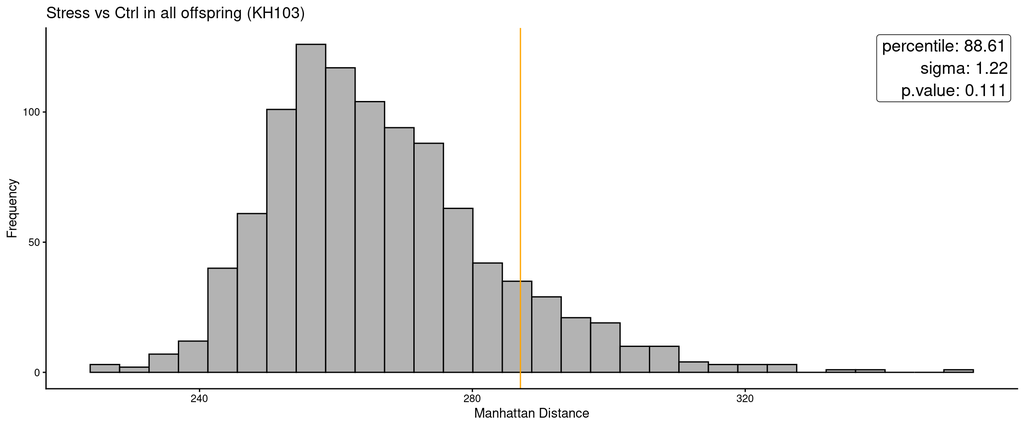

```r
  x <- plotTransVF(US_list$US_m_SvsC_K, labels = "kmeans.50",title = "Stress vs Ctrl in all offspring (KH103)")
  print(x)
```

```r
ggsave("plots/FigS5GC_Perm_Trans_male_SvsCinKH103.png")
  ggsave("plots/FigS5GC_Perm_Trans_male_SvsCinKH103.svg")
   ggsave("plots/FigS5GC_Perm_Trans_male_SvsCinKH103.pdf")
```

## 28.7 Fig S5H Classic Behavior all offspring

read in behavior data

```r
df <- readRDS("objects/OFT_readout.rds")
df$condition <- as.character(df$condition)

df$condition[df$condition == "non.stressed.PROTAC"] <- "Control-KH103"

df$condition[df$condition == "non.stressed.DMSO"] <- "Control-DMSO"

df$condition[df$condition == "stressed.PROTAC"] <- "Stress-KH103"
df$condition[df$condition == "stressed.DMSO"] <- "Stress-DMSO"

df$condition <- factor(df$condition, levels = c("Control-DMSO", "Stress-DMSO", "Control-KH103", "Stress-KH103"))
```

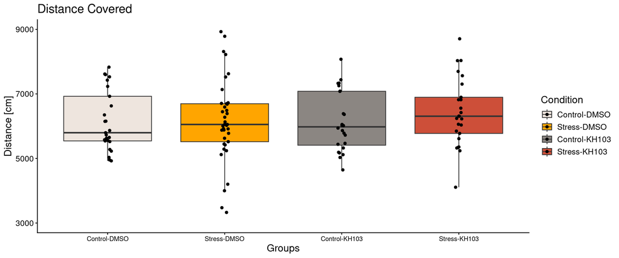

```r
behavior <- "bodycentre.distance.moving"
  # Calculate range and breaks
  y_min <- (min(df[[behavior]]))
  y_max <- (max(df[[behavior]]))
  y_breaks <- seq(3000, 9000, length.out = 4)

  # Round to nearest 0.5
  # round_to_half <- function(x) round(x * 2,digits = 1) / 2
  # y_breaks <- round_to_half(y_breaks)
  #
  # Adjust limits to match rounded breaks
  y_lim <- range(y_breaks)



  e <- ggplot(df, aes(x = condition, y = df[[behavior]], fill = condition))


   e2 <- e + geom_boxplot(width = 0.75,outlier.shape = NA ) +
     geom_jitter(
     position=position_jitterdodge(jitter.width = 0.1, dodge.width = 0.75)
      )+

     ylab("Distance [cm]")+
     xlab("Groups")+
     ggtitle(paste0("Distance Covered"))+



  scale_y_continuous(breaks = y_breaks, limits = y_lim) +


     scale_fill_manual(values=c( "seashell2","#ffa500ff","seashell4","tomato3"))+
     labs(fill= "Condition")+

   theme(
    axis.text.x = element_text(size = 9),
    text = element_text(size = 14),
  )


   print(e2)
```

```r
#
ggsave("plots/FigS5H_DistanceCovered_all_offspring.svg")
ggsave("plots/FigS5H_DistanceCovered_all_offspring.pdf")
ggsave("plots/FigS5H_DistanceCovered_all_offspring.png")
```

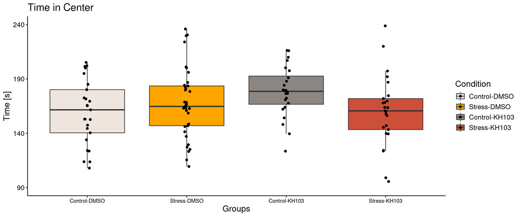

```r
behavior <- "tic1"
  # Calculate range and breaks
  y_min <- (min(df[[behavior]]))
  y_max <- (max(df[[behavior]]))
  y_breaks <- seq(90, 240, length.out = 4)

  # Round to nearest 0.5
  # round_to_half <- function(x) round(x * 2,digits = 1) / 2
  # y_breaks <- round_to_half(y_breaks)
  #
  # Adjust limits to match rounded breaks
  y_lim <- range(y_breaks)



  e <- ggplot(df, aes(x = condition, y = df[[behavior]], fill = condition))


   e2 <- e + geom_boxplot(width = 0.75,outlier.shape = NA ) +
     geom_jitter(
     position=position_jitterdodge(jitter.width = 0.1, dodge.width = 0.75)
      )+

     ylab("Time [s]")+
     xlab("Groups")+
     ggtitle(paste0("Time in Center"))+



  scale_y_continuous(breaks = y_breaks, limits = y_lim) +


     scale_fill_manual(values=c( "seashell2","#ffa500ff","seashell4","tomato3"))+
     labs(fill= "Condition")+

   theme(
    axis.text.x = element_text(size = 9),
    text = element_text(size = 14),
  )


   print(e2)
```

```r
ggsave("plots/FigS5H_TIC_all_offspring.svg")
ggsave("plots/FigS5H_TIC_all_offspring.pdf")
ggsave("plots/FigS5H_TIC_all_offspring.png")
```

## 28.8 Fig S5I Classic Behavior male offspring

read in behavior data

```r
df <- readRDS("objects/OFT_readout.rds")
df$condition <- as.character(df$condition)

df$condition[df$condition == "non.stressed.PROTAC"] <- "Control-KH103"

df$condition[df$condition == "non.stressed.DMSO"] <- "Control-DMSO"

df$condition[df$condition == "stressed.PROTAC"] <- "Stress-KH103"
df$condition[df$condition == "stressed.DMSO"] <- "Stress-DMSO"

df$condition <- factor(df$condition, levels = c("Control-DMSO", "Stress-DMSO", "Control-KH103", "Stress-KH103"))
```

```r
df <- df[df$sex == "m",]
```

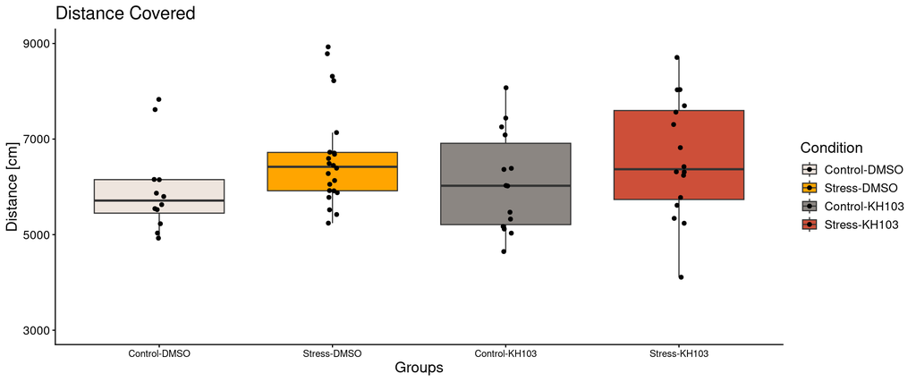

```r
behavior <- "bodycentre.distance.moving"
  # Calculate range and breaks
  y_min <- (min(df[[behavior]]))
  y_max <- (max(df[[behavior]]))
  y_breaks <- seq(3000, 9000, length.out = 4)

  # Round to nearest 0.5
  # round_to_half <- function(x) round(x * 2,digits = 1) / 2
  # y_breaks <- round_to_half(y_breaks)
  #
  # Adjust limits to match rounded breaks
  y_lim <- range(y_breaks)



  e <- ggplot(df, aes(x = condition, y = df[[behavior]], fill = condition))


   e2 <- e + geom_boxplot(width = 0.75,outlier.shape = NA ) +
     geom_jitter(
     position=position_jitterdodge(jitter.width = 0.1, dodge.width = 0.75)
      )+

     ylab("Distance [cm]")+
     xlab("Groups")+
     ggtitle(paste0("Distance Covered"))+



  scale_y_continuous(breaks = y_breaks, limits = y_lim) +


     scale_fill_manual(values=c( "seashell2","#ffa500ff","seashell4","tomato3"))+
     labs(fill= "Condition")+

   theme(
    axis.text.x = element_text(size = 9),
    text = element_text(size = 14),
  )


   print(e2)
```

```r
#
ggsave("plots/Fig4K_DistanceCovered_m_offspring.svg")
ggsave("plots/Fig4K_DistanceCovered_m_offspring.pdf")
ggsave("plots/Fig4K_DistanceCovered_m_offspring.png")
```

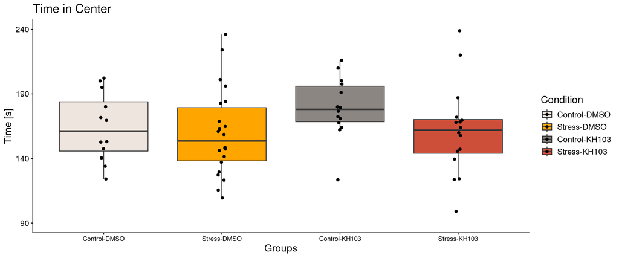

```r
behavior <- "tic1"
  # Calculate range and breaks
  y_min <- (min(df[[behavior]]))
  y_max <- (max(df[[behavior]]))
  y_breaks <- seq(90, 240, length.out = 4)

  # Round to nearest 0.5
  # round_to_half <- function(x) round(x * 2,digits = 1) / 2
  # y_breaks <- round_to_half(y_breaks)
  #
  # Adjust limits to match rounded breaks
  y_lim <- range(y_breaks)



  e <- ggplot(df, aes(x = condition, y = df[[behavior]], fill = condition))


   e2 <- e + geom_boxplot(width = 0.75,outlier.shape = NA ) +
     geom_jitter(
     position=position_jitterdodge(jitter.width = 0.1, dodge.width = 0.75)
      )+

     ylab("Time [s]")+
     xlab("Groups")+
     ggtitle(paste0("Time in Center"))+



  scale_y_continuous(breaks = y_breaks, limits = y_lim) +


     scale_fill_manual(values=c( "seashell2","#ffa500ff","seashell4","tomato3"))+
     labs(fill= "Condition")+

   theme(
    axis.text.x = element_text(size = 9),
    text = element_text(size = 14),
  )


   print(e2)
```

```r
ggsave("plots/Fig4I_TIC_m_offspring.svg")
ggsave("plots/Fig4I_TIC_m_offspring.pdf")
ggsave("plots/Fig4I_TIC_m_offspring.png")
```

## 28.9 Fig S6A Human Sperm Data compared to publicly available data

action required

```r
 bw_list <- list.files(path = "extern_data/",pattern = "Corces(.*)full.bw$",full.names = T)
 names <- gsub(x = basename(bw_list),pattern = "\\.bam|.bw",replacement = "")
 names(bw_list) <- names
bw_Corces <- bw_list
```

subset human for full tracks

```r
bw_list <- list.files(path = "intern_data/ATAC_Hs/",pattern = "full.bw$",full.names = T)
bw_list <- bw_list[grepl(pattern = "bam",x = bw_list)]
names <- gsub(x = basename(bw_list),pattern = "\\.bam|.bw",replacement = "")
names(bw_list) <- names

bw_Human <- bw_list[-5]
```

```r
resizedPeaks300 <- readRDS("objects/narrowPeaks_allHumanHighLow5_resized_300bp.SE.rds") ## this

gr <- granges(resizedPeaks300)
```

```r
set.seed(123)


peaks_Human_merge <- sample(gr,10000)

seqlevelsStyle(peaks_Human_merge) <- "Ensembl"

sm <- signal2Matrix(c(bw_Human,bw_Corces),regions = peaks_Human_merge,w = 20L)
sm_norm <- renormalizeSignalMatrices(sm) # basic normalization
```

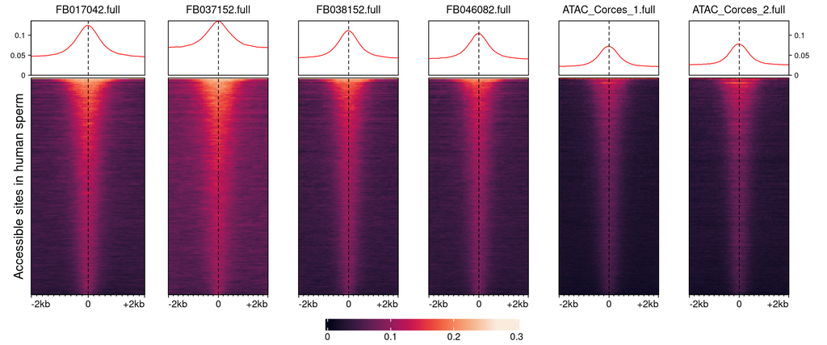

```r
p <-  plotEnrichedHeatmaps(sm,row_title = "Accessible sites in human sperm",scale_title = "GR\ndesnity",colors = rocket(2000), raster_resize_mat = TRUE, use_raster = TRUE,axis_name = c("-2kb","0","+2kb"),width = unit(0.8,"npc"), heatmap_legend_param = list(legend_direction = "horizontal", legend_width = unit(0.4,"npc"), title=NULL))



  draw(p, heatmap_legend_side="bottom", annotation_legend_side="right",  legend_grouping = "original")
```

```r
  png(paste0("plots/FigS6A_comparision_ATAC_literature.png"), width=750, height=500)
  draw(p, heatmap_legend_side="bottom", annotation_legend_side="right",  legend_grouping = "original")
  dev.off()
```

```r
  # pdf(paste0("plots/FigS6A_comparision_ATAC_literature.pdf"), width=7.5, height=5)
  # draw(p, heatmap_legend_side="bottom", annotation_legend_side="right",  legend_grouping = "original")
  # dev.off()
  #
  # svg(paste0("plots/FigS6A_comparision_ATAC_literature.svg"), width=7.5, height=5)
  # draw(p, heatmap_legend_side="bottom", annotation_legend_side="right",  legend_grouping = "original")
  # dev.off()
```

## 28.10 Fig S6B GSEA High-TADS vs Low-TADS

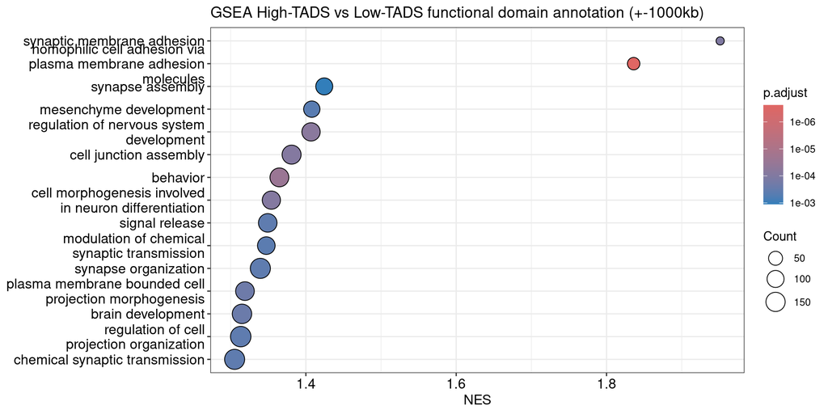

```r
simply_great<- readRDS("intern_data/ATAC_Hs/greatGSEA_simply.rds")


dotplot(simply_great,showCategory = 15,x = "NES") + ggtitle("GSEA High-TADS vs Low-TADS functional domain annotation (+-1000kb)")
```

```r
ggsave("plots/FigS6B_GSEA_GreatAnno.png")
# ggsave("plots/FigS6B_GSEA_GreatAnno.svg")
# ggsave("plots/FigS6B_GSEA_GreatAnno.pdf")
```

## 28.11 Fig S6C GR-like motif comparison

```r
motifs$GCR
```

```
##
##        Motif name:   GCR.H14CORE.0.PS.A
##          Alphabet:   DNA
##              Type:   PPM
##           Strands:   +-
##          Total IC:   17.26
##       Pseudocount:   1
##         Consensus:   NRGNACAYNRTGTWCYNNN
##      Target sites:   1686
##
##      N    R    G    N    A    C    A    Y    N    R    T G T    W C    Y    N
## A 0.25 0.60 0.04 0.38 0.97 0.01 0.89 0.14 0.35 0.52 0.02 0 0 0.47 0 0.09 0.18
## C 0.27 0.10 0.01 0.08 0.01 0.98 0.01 0.31 0.20 0.09 0.02 0 0 0.03 1 0.59 0.32
## G 0.25 0.28 0.94 0.20 0.01 0.01 0.09 0.07 0.19 0.28 0.00 1 0 0.00 0 0.02 0.17
## T 0.23 0.02 0.01 0.33 0.01 0.01 0.02 0.48 0.26 0.11 0.95 0 1 0.50 0 0.29 0.33
##      N    N
## A 0.19 0.22
## C 0.10 0.19
## G 0.29 0.27
## T 0.43 0.32
```

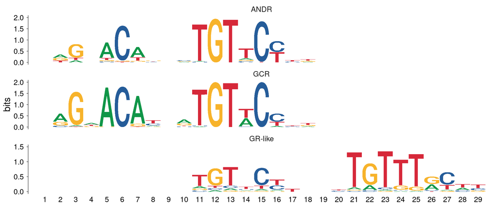

```r
m <- convert_motifs(motifs, class = "universalmotif-universalmotif")

m1 <- motifs$ANDR
m1@name <- "ANDR"

m2 <- motifs$GCR
m2@name <- "GCR"


m3 <- motifs_cluster$ANDR.H14CORE.2.P.B
m3@name <- "GR-like"



library(ggh4x)
p <- view_motifs(c(m1,m2,m3),method = "ALLR_LL",normalise.scores = F)
p + facet_wrap2(p$facet$params$facets, ncol = 1, scales = "free_y") +
  facetted_pos_scales(y = list(
    scale_y_continuous(limits = c(0, 2)),     # ANDR
    scale_y_continuous(limits = c(0, 2)),     # GCR
    scale_y_continuous(limits = c(0, 1.5)) ))   # GR-like
```

```r
ggsave("plots/FigS6C_GSEA_GreatAnno.png")
ggsave("plots/FigS6C_GSEA_GreatAnno.svg")
ggsave("plots/FigS6C_GSEA_GreatAnno.pdf")
```

## 28.12 Fig S6D Covariate analysis for TADS-groups

```r
se <- readRDS("intern_data/ATAC_Hs/narrowPeaks_allHumanHighLow5.SE.rds")


# summary(assay(se)[,1])
se$names <- gsub(x = colnames(se),pattern = "\\_(.*)",replacement = "")
meta <- read.csv("intern_data/ATAC_Hs/meta.csv",sep = ",")



rownames(meta) <- meta$FB_ID
meta <- meta[complete.cases(meta),]
meta <- meta[se$names,]
colData(se) <- DataFrame(meta[se$names,])


rownames(se) <- as.character(granges(se))
```

```r
dds <- calcNormFactors(DGEList(assay(se)))
mm <- model.matrix(~0+TADS_group, data=as.data.frame(colData(se))); mm
```

```
##          TADS_grouphigh TADS_grouplow
## FB010532              1             0
## FB013732              1             0
## FB024682              1             0
## FB027522              1             0
## FB028472              0             1
## FB030412              0             1
## FB031382              0             1
## FB032122              0             1
## FB034072              0             1
## FB035892              0             1
## FB038532              0             1
## FB038582              1             0
## FB039372              0             1
## FB042572              1             0
## FB043592              1             0
## FB047372              1             0
## FB017042              1             0
## FB037152              0             1
## FB038152              0             1
## FB046082              1             0
## attr(,"assign")
## [1] 1 1
## attr(,"contrasts")
## attr(,"contrasts")$TADS_group
## [1] "contr.treatment"
```

```r
dds <- dds[filterByExpr(dds,group =  se$TADS_group, min.count=10),]


se <- se[rownames(dds),]

# logCPM
assays(se)$logcpm <- log1p(edgeR::cpm(dds))
```

```r
# PCA: samples need to be rows
pca <- prcomp(t(assays(se)$logcpm), scale. = FALSE)

pcs <- as.data.frame(pca$x[, 1:5])
summary(pca)$importance[2, 1:5]
```

```
##     PC1     PC2     PC3     PC4     PC5
## 0.27785 0.16503 0.05429 0.04647 0.04205
```

```r
meta <- as.data.frame(colData(se))

dat <- cbind(meta, pcs)

dat$TADS_group      <- factor(dat$TADS_group)
dat$smoking_yes1_no0 <- factor(dat$smoking_yes1_no0)
dat$SequencingLane1  <- factor(dat$SequencingLane1)
```

```r
vars <- c(
    "Age_yhd",
    "smoking_yes1_no0",
    "alkohol_avg_daily",
    "Semen_vol_ml",
    "concentration_10exp6_ml",
    "SequencingLane1",
    "bmi_epig",
    "siviilisaaty_epig",
    "epdssum_epig",
    "sclsum_epig"
)

adjR2 <- sapply(paste0("PC", 1:5), function(pc) {
    sapply(vars, function(v) {
        fit <- lm(
            reformulate(v, response = pc),
            data = dat
        )
        summary(fit)$adj.r.squared
    })
})

round(adjR2, 2)
```

```
##                           PC1   PC2   PC3   PC4   PC5
## Age_yhd                  0.03 -0.04  0.08 -0.02 -0.04
## smoking_yes1_no0         0.00  0.05 -0.05 -0.01  0.06
## alkohol_avg_daily       -0.05  0.22 -0.05 -0.04 -0.04
## Semen_vol_ml             0.09  0.00 -0.04 -0.05 -0.03
## concentration_10exp6_ml -0.05  0.00 -0.05 -0.04 -0.01
## SequencingLane1          0.44 -0.29 -0.12  0.18  0.20
## bmi_epig                -0.05 -0.01 -0.06 -0.03 -0.05
## siviilisaaty_epig       -0.05 -0.03  0.07 -0.03 -0.05
## epdssum_epig            -0.05 -0.02 -0.05 -0.05 -0.05
## sclsum_epig              0.02 -0.01  0.04 -0.05  0.14
```

```r
pvals <- sapply(paste0("PC", 1:5), function(pc) {
    sapply(vars, function(v) {
        fit <- lm(reformulate(v, response = pc), data = dat)
        f <- summary(fit)$fstatistic
        pf(f[1], f[2], f[3], lower.tail = FALSE)
    })
})
```

```r
var_explained <- summary(pca)$importance[2, 1:5]

round(var_explained, 3)
```

```
##   PC1   PC2   PC3   PC4   PC5
## 0.278 0.165 0.054 0.046 0.042
```

```r
TADS_R2 <- sapply(vars, function(v) {
    fit <- lm(
        reformulate(v, response = "TADS_score"),
        data = dat
    )

    summary(fit)$adj.r.squared

})

res <- cbind(
    TADS = TADS_R2,
    adjR2
)

round(res, 2)
```

```
##                          TADS   PC1   PC2   PC3   PC4   PC5
## Age_yhd                  0.05  0.03 -0.04  0.08 -0.02 -0.04
## smoking_yes1_no0         0.10  0.00  0.05 -0.05 -0.01  0.06
## alkohol_avg_daily        0.20 -0.05  0.22 -0.05 -0.04 -0.04
## Semen_vol_ml             0.13  0.09  0.00 -0.04 -0.05 -0.03
## concentration_10exp6_ml -0.03 -0.05  0.00 -0.05 -0.04 -0.01
## SequencingLane1         -0.06  0.44 -0.29 -0.12  0.18  0.20
## bmi_epig                 0.02 -0.05 -0.01 -0.06 -0.03 -0.05
## siviilisaaty_epig       -0.02 -0.05 -0.03  0.07 -0.03 -0.05
## epdssum_epig             0.00 -0.05 -0.02 -0.05 -0.05 -0.05
## sclsum_epig             -0.06  0.02 -0.01  0.04 -0.05  0.14
```

```r
TADS_p <- sapply(vars, function(v) {
    fit <- lm(reformulate(v, response = "TADS_score"), data = dat)
    f <- summary(fit)$fstatistic
    pf(f[1], f[2], f[3], lower.tail = FALSE)
})

res_p <- cbind(
    TADS = TADS_p,
    pvals
)

signif(res_p, 2)
```

```
##                                TADS   PC1  PC2  PC3  PC4   PC5
## Age_yhd.value                 0.180 0.240 0.59 0.13 0.44 0.630
## smoking_yes1_no0.value        0.091 0.350 0.17 0.68 0.41 0.160
## alkohol_avg_daily.value       0.026 0.790 0.02 0.79 0.63 0.630
## Semen_vol_ml.value            0.066 0.110 0.33 0.66 0.92 0.530
## concentration_10exp6_ml.value 0.490 0.830 0.34 0.72 0.64 0.370
## SequencingLane1.value         0.570 0.028 0.93 0.68 0.20 0.170
## bmi_epig.value                0.250 0.840 0.41 1.00 0.50 0.750
## siviilisaaty_epig.value       0.410 0.920 0.48 0.14 0.55 0.920
## epdssum_epig.value            0.350 0.720 0.45 0.84 0.74 0.720
## sclsum_epig.value             0.960 0.260 0.38 0.20 0.84 0.059
```

```r
round(res, 2)
```

```
##                          TADS   PC1   PC2   PC3   PC4   PC5
## Age_yhd                  0.05  0.03 -0.04  0.08 -0.02 -0.04
## smoking_yes1_no0         0.10  0.00  0.05 -0.05 -0.01  0.06
## alkohol_avg_daily        0.20 -0.05  0.22 -0.05 -0.04 -0.04
## Semen_vol_ml             0.13  0.09  0.00 -0.04 -0.05 -0.03
## concentration_10exp6_ml -0.03 -0.05  0.00 -0.05 -0.04 -0.01
## SequencingLane1         -0.06  0.44 -0.29 -0.12  0.18  0.20
## bmi_epig                 0.02 -0.05 -0.01 -0.06 -0.03 -0.05
## siviilisaaty_epig       -0.02 -0.05 -0.03  0.07 -0.03 -0.05
## epdssum_epig             0.00 -0.05 -0.02 -0.05 -0.05 -0.05
## sclsum_epig             -0.06  0.02 -0.01  0.04 -0.05  0.14
```

```r
# pmat = p-value matrix, r2mat = adjusted R² matrix (same dims, same order)
pmat  <- as.matrix(res_p[,1:4])
r2mat <- as.matrix(res[,1:4])

rownames(pmat) <- c("age","smoking","alcohol","semen volume","semen conc.","seq. lane","BMI","civil status","depression score", "anxiety score")
rownames(r2mat) <-  c("age","smoking","alcohol","semen volume","semen conc.","seq. lane","BMI","civil status","depression score", "anxiety score")
# Ensure alignment: p-value rownames carry a ".value" suffix
rownames(pmat) <- sub("\\.value$", "", rownames(pmat))
pmat <- pmat[rownames(r2mat), colnames(r2mat)]

# Negative adj. R² = no explanatory power -> 0
mat <- pmax(r2mat, 0)
mat <- r2mat
```

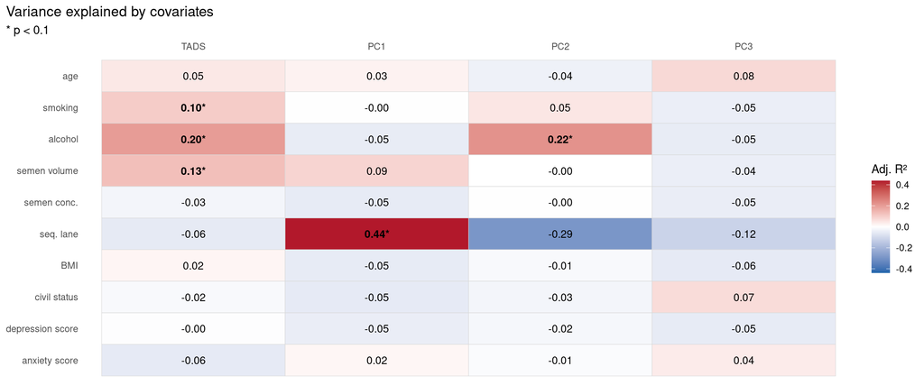

```r
library(tibble)
library(tidyr)
alpha <- 0.1
plot_df <- as.data.frame(r2mat) %>%
  rownames_to_column("Covariate") %>%
  pivot_longer(-Covariate, names_to = "Outcome", values_to = "r2") %>%
  left_join(
    as.data.frame(pmat) %>%
      rownames_to_column("Covariate") %>%
      pivot_longer(-Covariate, names_to = "Outcome", values_to = "p"),
    by = c("Covariate", "Outcome")
  ) %>%
  mutate(
    star  = !is.na(.data$p) & .data$p < alpha,
    label = paste0(sprintf("%.2f", r2), if_else(star, "*", "")),
    Covariate = factor(Covariate, levels = rev(rownames(r2mat))),
    Outcome   = factor(Outcome, levels = colnames(r2mat))
  )

lim <- max(abs(plot_df$r2))

ggplot(plot_df, aes(Outcome, Covariate, fill = r2)) +
  geom_tile(color = "grey85") +
  geom_text(aes(label = label, fontface = if_else(star, "bold", "plain")),
            size = 3.5) +
  scale_fill_gradient2(low = "#2166AC", mid = "white", high = "#B2182B",
                       midpoint = 0, limits = c(-lim, lim), name = "Adj. R²") +
  scale_x_discrete(position = "top") +
  labs(x = NULL, y = NULL,
       title = "Variance explained by covariates",
       subtitle = paste0("* p < ", alpha)) +
  theme_minimal(base_size = 11) +
  theme(panel.grid = element_blank(),
        plot.title.position = "plot")
```

```r
ggsave("plots/FigS6D_covariate_variance_matrix.png")
# ggsave("plots/FigS6D_covariate_variance_matrix.pdf")
# ggsave("plots/FigS6D_covariate_variance_matrix.svg")
```

```r
tmp <- as.data.frame(r2mat) %>%
  rownames_to_column("Covariate") %>%
  pivot_longer(-Covariate, names_to = "Outcome", values_to = "r2") %>%
  left_join(
    as.data.frame(pmat) %>%
      rownames_to_column("Covariate") %>%
      pivot_longer(-Covariate, names_to = "Outcome", values_to = "p"),
    by = c("Covariate", "Outcome")
  )

str(tmp)
```

```
## tibble [40 × 4] (S3: tbl_df/tbl/data.frame)
##  $ Covariate: chr [1:40] "age" "age" "age" "age" ...
##  $ Outcome  : chr [1:40] "TADS" "PC1" "PC2" "PC3" ...
##  $ r2       : num [1:40] 0.0468 0.0253 -0.0383 0.0763 0.1033 ...
##  $ p        : num [1:40] 0.181 0.238 0.591 0.126 0.091 ...
```

```r
names(tmp)
```

```
## [1] "Covariate" "Outcome"   "r2"        "p"
```

```r
tmp$p
```

```
##  [1] 0.18130482 0.23753154 0.59080359 0.12640447 0.09100815 0.34547526
##  [7] 0.17489930 0.67593951 0.02639301 0.78659485 0.02033905 0.78608636
## [13] 0.06577941 0.11122661 0.33344313 0.66015472 0.49457443 0.82856742
## [19] 0.34337500 0.71748385 0.56664212 0.02836172 0.93419953 0.68067104
## [25] 0.25204297 0.84422934 0.40605308 0.99962836 0.40984123 0.92142072
## [31] 0.48447746 0.13593771 0.34925441 0.71870363 0.44667691 0.83757065
## [37] 0.95995873 0.25820494 0.38253380 0.19788927
```

```r
form <- ~ TADS_group +
          Age_yhd +
          smoking_yes1_no0 +
          alkohol_avg_daily +
          Semen_vol_ml +
          concentration_10exp6_ml +
          SequencingLane1  +
          epdssum_epig +
          sclsum_epig +
          bmi_epig


library(vegan)
d <- dist(t(assays(se)$logcpm), method = "euclidean")
form_adonis <- as.formula(
    paste(
        "d ~",
        paste(attr(terms(form), "term.labels"), collapse = " + ")
    )
)
```

```r
set.seed(1)  # permutation p-values are random; fix the seed for reproducibility
nperm <- 9999  # 999 is too coarse for p-values near 0.05

run <- function(f) adonis2(f, data = meta, permutations = nperm, by = "margin")

fits <- list(
  "No covariates"            = run(d ~ TADS_group),
  "Lane"                     = run(d ~ TADS_group + SequencingLane1),
  "Lane + alcohol"           = run(d ~ TADS_group + SequencingLane1 + alkohol_avg_daily),
  "Lane + smoking"           = run(d ~ TADS_group + SequencingLane1 + smoking_yes1_no0),
  "Lane + alcohol + smoking" = run(d ~ TADS_group + SequencingLane1 +
                                     alkohol_avg_daily + smoking_yes1_no0),
  # "Lane + SCL"               = run(d ~ TADS_group + SequencingLane1 + sclsum_epig),
  "Lane + semen volume"      = run(d ~ TADS_group + SequencingLane1 + Semen_vol_ml)
)



# One tidy object with everything
adonis_res <- purrr::imap_dfr(fits, function(fit, model) {
  as.data.frame(fit) %>%
    rownames_to_column("term") %>%
    dplyr::filter(!term %in% c("Residual", "Total")) %>%
    transmute(Model = model, term, R2, p = `Pr(>F)`)
}) %>%
  mutate(
    Variable = recode(term,
      TADS_group        = "TADS",
      SequencingLane1   = "Sequencing lane",
      alkohol_avg_daily = "Alcohol",
      smoking_yes1_no0  = "Smoking",
      # sclsum_epig       = "SCL-90",
      Semen_vol_ml      = "Semen volume"),
    Model = factor(Model, levels = names(fits)),
    sig = case_when(p < 0.001 ~ "***", p < 0.01 ~ "**",
                    p < 0.05 ~ "*", p < 0.1 ~ ".", TRUE ~ "")
  ) %>%
  dplyr::select(Model, Variable, R2, p, sig)
```

```r
adonis_res %>%
  filter(Variable == "TADS") %>%
  ggplot(aes(x = reorder(Model, R2), y = R2)) +

  geom_col(
    aes(fill = p < 0.05),
    width = 0.7
  ) +

  geom_text(
    aes(label = paste0(
      "R² = ", sprintf("%.3f", R2),
      "\np = ", sprintf("%.3f", p)
    )),
    hjust = -0.05,
    size = 3.5
  ) +

  coord_flip() +

  scale_fill_manual(
    values = c("FALSE" = "grey70", "TRUE" = "#D55E00"),
    guide = "none"
  ) +

  expand_limits(y = 0.105) +

  labs(
    x = NULL,
    y = expression("Marginal TADS " * R^2),
    title = "TADS effect across covariate-adjusted PERMANOVA models"
  ) +

  theme_classic(base_size = 12)
```

[output not shown]

[output not shown]

```r
ggsave("plots/FigS6D_covariate_variance_model.png")
# ggsave("plots/FigS6D_covariate_variance_model.pdf")
# ggsave("plots/FigS6D_covariate_variance_model.svg")
```